# Exploring Regression Models for Predicting University Students’ Academic Outcomes

Christine Killion

March 5, 2025

# 1 Introduction

The purpose of this report is to apply a machine learning approach to building regression models that predict student academic outcomes. The report draws from data and research by the authors of *Early Prediction of Student’s Performance in Higher Education: A Case Study*.<sup>1</sup>

The questions I will seek to answer in this report are two-fold: First, do macroeconomic factors have any predictive influence on a student’s grades and thus whether they should be considered in machine learning models to predict student academic performance? Secondly, what factors effectively predict whether a student drops out of their course of study?

In this report, I use exploratory data analysis to examine the features in the dataset that may potentially help predict student academic performance. Understanding the distributions of the features and the relationships between them may help inform the development of machine learning models that more accurately predict academic outcome while mitigating bias. The latter portion of the report is dedicated to using this information to engineer the features and develop predictive regression models for student outcomes, measured by second-semester grade average and dropout status.

# 2 Exploratory Data Analysis

This dataset contains features provided by a higher education institution in Portugal and collected from various disjoint databases about students at the time of their enrollment in an undergraduate degree program. The features relate to student and parent demographics, socioeconomic indicators, course of study, academic performance, and the targeted outcome: whether a student graduates, drops out, or remains enrolled. The collected data previously underwent cleaning and numerical recoding to prepare it for the modeling task of classification. However, instead of classification, this report will focus on regression problems.<sup>2</sup>

## 2.1 List of Features

The dataset contains 4,424 observations and 34 feature features.

- **Marital Status** (categorical): 6 categories include single, married, widower, divorced, de facto union, or legally separated; 88.6% of students are categorized as single.
- **Application mode** (categorical): 18 categories include information related to the student’s application classifiers, such as international student, special contingent, special age category, and transfer student.
- **Application order** (categorical): 8 categories of preferred application order between first choice and last choice.
- **Course** (categorical): 17 categories for chosen course of study.
- **Daytime/evening attendance** (binary): Whether a student attends during the day or in the evening; 89.08% attend during the day.
- **Previous Qualification** (categorical): 17 categories of highest education level, from secondary education to master’s degree; 84.02% of students completed their secondary education (12th year of schooling or equivalent).
- **Nationality** (categorical): 21 nationalities represented, 97.5% Portuguese and the remaining international students.
- **Mother’s Qualification** and **Father’s Qualification** (categorical): 29 and 34 categories of highest education level, respectively.
- **Mother’s Occupation** and **Father’s Occupation** (categorical): 32 and 46 categories of occupation, respectively.
- **Displaced** (binary): Whether or not a student is displaced; 54.84% of students are displaced.
- **Educational special needs** (binary): 1.15% of students reported educational special needs.
- **Debtor** (binary): Whether or not a student has debt; 11.37% of students have debt.
- **Tuition fees up to date** (binary): Whether or not a student’s tuition fees are up to date; 11.93% are not up-to-date on their payments.
- **Gender** (binary): 64.83% of students are female
- **Scholarship holder** (binary): 24.84% of students hold a scholarship.
- **Age at enrollment** (integer): Age of the student when they are enrolled; 64.94% are 21 years old or younger.
- **International student** (binary): International students (i.e., not from Portugal) account for 2.49% of the sample.
- **Curricular Units 1st Semester** and **Curricular Units 2nd Semester** (integers): Number of curricular units **Credited**, **Enrolled**, and **Approved** for each semester. **Evaluations** encompasses the number of evaluations to curricular units in each semester, and **Without Evaluations** is the number of curricular units without evaluations in each semester. **Grade** is the average grade between 0 and 20 per semester.
- Economic features (continuous): This dataset includes continuous features related to the **Unemployment Rate**, **Inflation Rate**, and **GDP**.
- **Target** (categorical): A student’s academic outcome classified across three categories: Dropout, graduate, and enrolled.

```r
data <- read.csv("https://christinekillion.github.io/machine_learning/data/student-success.csv")

# Change column names
colnames(data) <- c(
  "Marital", "Application_M", "Application_O", "Course",
  "Attendance", "S_Qual", "Nationality",
  "M_Qual", "F_Qual", "M_Occ",
  "F_Occ", "Displaced", "Special_Needs", "Debtor",
  "Tuition", "Gender", "Scholarship", "Age",
  "International", "U_Credited1", "U_Enrolled1",
  "U_Evaluated1", "U_Approved1",
  "Grade1", "U_WO_Eval1",
  "U_Credited2", "U_Enrolled2",
  "U_Evaluated2", "U_Approved2",
  "Grade2", "U_WO_Eval2",
  "Unemployment", "Inflation", "GDP", "Target"
)

# Create random observation ID and replace 8% of the corresponding observations with missing values
grades1.missing.id <- sample(1:4424, 353, replace = FALSE)
grades2.missing.id <- sample(1:4424, 354, replace = FALSE)
data$Grade1[grades1.missing.id] <- NA
data$Grade2[grades2.missing.id] <- NA

#Total the number of missing values per column.
missing_per_column <- colSums(is.na(data))

#Total the number of missing values in the dataset.
total_missing <- sum(is.na(data))
```

## 2.2 Distribution of Individual Features

This section will describe the univariate distributions of the key categorical, binary, and continuous features in the dataset and highlight potential issues for regression modeling.

**Student Groups of Interest**

There are three key groups that are underrepresented within this dataset and should be carefully considered in the development of machine learning models so as not to reproduce bias. Section 2.3 of this report explores in more detail the relationship between these groups and academic achievement.

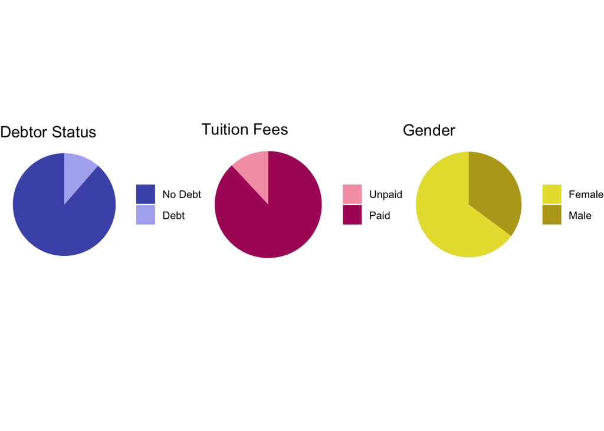

```r
# Count the number of occurrences for each category
debtor_counts <- table(data$Debtor)
tuition_counts <- table(data$Tuition)
gender_counts <- table(data$Gender)

# Create data frames from the counts for each category
debtor_df <- as.data.frame(debtor_counts)
tuition_df <- as.data.frame(tuition_counts)
gender_df <- as.data.frame(gender_counts)

# Recode binary values from numbers to categories
debtor_df$Var1 <- recode(debtor_df$Var1, `1` = "Debt", `0` = "No Debt")
tuition_df$Var1 <- recode(tuition_df$Var1, `1` = "Paid", `0` = "Unpaid")
gender_df$Var1 <- recode(gender_df$Var1, `1` = "Male", `0` = "Female")

# Create the pie charts with ggplot2

# Debtor Pie Chart
pie_debtor <- ggplot(debtor_df, aes(x = "", y = Freq, fill = Var1)) +
  geom_bar(stat = "identity", width = 1) +
  coord_polar(theta = "y") +  # Convert bar chart to pie chart
  scale_fill_manual(values = c("#4C57B8", "#AFB1F0")) +
  theme_void() +  # Remove background and axes
  guides(fill = guide_legend(title = NULL)) +  # Add legend and remove title
  ggtitle("Debtor Status")  # Remove individual title

# Tuition Fees Pie Chart
pie_tuition <- ggplot(tuition_df, aes(x = "", y = Freq, fill = Var1)) +
  geom_bar(stat = "identity", width = 1) +
  coord_polar(theta = "y") +  # Convert bar chart to pie chart
  scale_fill_manual(values = c("#F5A1B5", "#ac1f67")) +
  theme_void() +  # Remove background and axes
  guides(fill = guide_legend(title = NULL)) +  # Add legend and remove title
  ggtitle("Tuition Fees")  # Remove individual title

# Gender Pie Chart
pie_gender <- ggplot(gender_df, aes(x = "", y = Freq, fill = Var1)) +
  geom_bar(stat = "identity", width = 1) +
  coord_polar(theta = "y") +  # Convert bar chart to pie chart
  scale_fill_manual(values = c("#E6DE3C", "#B9A520")) +
  theme_void() +  # Remove background and axes
  guides(fill = guide_legend(title = NULL)) +  # Add legend and remove title
  ggtitle("Gender")

# Combine the pie charts into a grid with a centered main title
grid.arrange(
  pie_debtor, pie_tuition, pie_gender,
  ncol = 3,
  heights = unit(c(1, 0.1), "npc")  # Allocate space for the legends
)
```

**Parental Education and Occupation**

This dataset contains the previous academic qualifications of the student, mother, and father. For students, 84.02% have completed secondary education. The parental qualification distributions do not reflect that of the students: There is a wider range of educational categories for each of the parent groups (likely due to the disparate sources of data). When recoded and grouped into three main categories (secondary education, higher education, and other), the distribution of parent qualifications in the dataset indicates that most of the parent qualifications fall into the “other” category.

Parental occupation is similarly classified across a range of categories. Should parental education or occupation prove to be useful features in regression modeling, the granular categorization could potentially be an issue in the interpretability of a regression model.

**Grade Distribution**

The average grade features for each semester contain both missing values and values of zero. When grades of zero are excluded, the grade distributions are approximately normally distributed. Data imputation methods can be used to replace the missing and zero values. Additionally, a binary feature can be created to retain the information of whether a student has a recorded grade of zero for each semester (so as not to lose that information, which could potentially prove useful in regression model).

## 2.3 Relationship Between Features

This section examines the relationships between key categorical and numerical features in the dataset.

**Grades and Student Financials**

**Are the Student’s Tuition Fees Up to Date?**

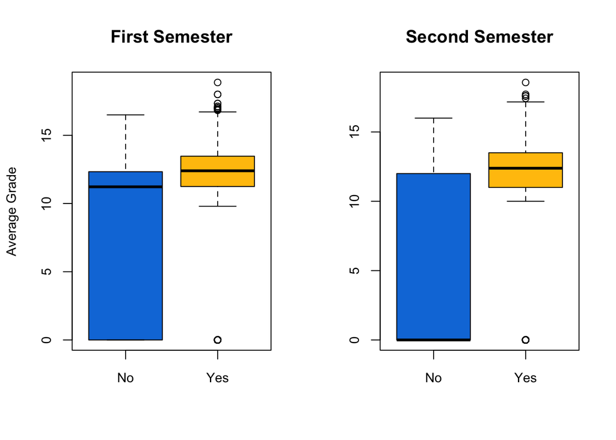

**Grades and Gender**

Male students, accounting for 35.17% of the dataset, appear to achieve a lower average grade distribution. Removing or imputating grade values of zero is recommended before modeling to help mitigate this bias.

**Distribution of Average Grades by Gender**

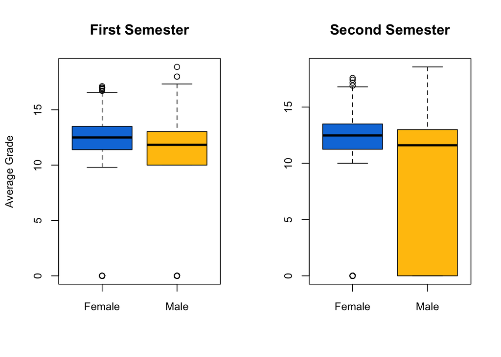

**Grades and Curricular Units**

This dataset includes multiple features measuring credits for each semester: i.e., number of curricular units credited, enrolled, approved, and evaluated. A significant number of the credited features for each semester have a value of zero, more so in the second semester; this may indicate that the information was recorded before the end of the second semester and may be incomplete. For this reason, I might consider only including approved curricular units as a potential feature in the model.

Further, note that when approved curricular unit is grouped and compared to student grades, it appears that students with between 4 and 8 curricular units approved achieve significantly higher grades than those with fewer than 4 and slightly higher grades on average than those more than 8. (Note that the number of evaluations to curricular units follows a similar trend).

This indicates that curricular units may be a relevant feature in predicting student academic outcomes. The features related to curricular units will need to be engineered to reduce dimensionality and prepare them for modeling.

```r
# Create Unit_Group1 based on U_Approved1
data$Unit_Group1 <- cut(data$U_Approved1,
                        breaks = c(-Inf, 0, 3, 8, Inf),
                        labels = c("0", "1-3", "4-8", "9+"),
                        right = TRUE)

# Create Unit_Group2 based on U_Approved2
data$Unit_Group2 <- cut(data$U_Approved2,
                        breaks = c(-Inf, 0, 3, 8, Inf),
                        labels = c("0", "1-3", "4-8", "9+"),
                        right = TRUE)
```

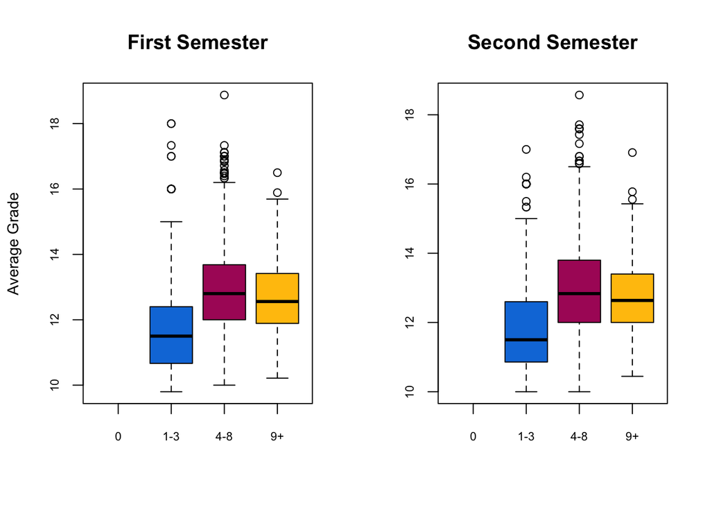

```r
col2 = c("#FFC20A", "#0C7BDC", "#ac1f67")

# Filter out "0" group from both Unit_Group1 and Unit_Group2
data_filtered1 <- data[data$Unit_Group1 != "0", ]
data_filtered2 <- data[data$Unit_Group2 != "0", ]

# Set up layout for the boxplots
par(mfrow = c(1, 2))  # 1 row, 2 columns

# Create the first boxplot for the first semester, excluding "0" group
boxplot(data_filtered1$Grade1 ~ data_filtered1$Unit_Group1,
        col = col2,
        main = "First Semester",
        xlab = " ",
        ylab = "Average Grade",
        cex.axis = 0.7,  # Smaller font size for axis labels
        cex.lab = 0.9)   # Smaller font size for axis titles

# Create the second boxplot for the second semester, excluding "0" group
boxplot(data_filtered2$Grade2 ~ data_filtered2$Unit_Group2,
        col = col2,
        main = "Second Semester",
        xlab = " ",
        ylab = " ",
        cex.axis = 0.7,  # Smaller font size for axis labels
        cex.lab = 0.9)   # Smaller font size for axis titles
```

# 3 Feature Engineering

What follows is a summary of the steps taken to engineer the key features in the dataset to prepare them for regression modeling.

I will begin by analyzing and addressing the missing values in the dataset and comparing the effectiveness of various imputation methods. I will then proceed to addressing issues with the key features, including combining and transforming grade features to normalize the distribution, merging information about curricular units to reduce dimensionality and improve interpretability, and transforming the target by establishing a binary, numerically encoded feature measuring whether a student drops out of their course of study.

```r
# Create random observation ID and replace 8% of the corresponding observations with missing values
grades1.missing.id <- sample(1:4424, 353, replace = FALSE)
grades2.missing.id <- sample(1:4424, 354, replace = FALSE)
data$Grade1[grades1.missing.id] <- NA
data$Grade2[grades2.missing.id] <- NA

# A "blank" answer for parent occupation is encoded as 13. Recode it as missing.
data <- data %>%
  mutate(M_Occ = ifelse(M_Occ == 13, NA, M_Occ))

data <- data %>%
  mutate(F_Occ = ifelse(F_Occ == 13, NA, F_Occ))

# Check for missing values in each column
invisible(colSums(is.na(data)))
```

## 3.1 Missing Values

```r
# Create the Zero1 feature (1 if Grade1 is 0, otherwise 0, including NAs as 0)
data$Zero1 <- ifelse(!is.na(data$Grade1) & data$Grade1 == 0, 1, 0)

# Create the Zero2 feature (1 if Grade2 is 0, otherwise 0, including NAs as 0)
data$Zero2 <- ifelse(!is.na(data$Grade2) & data$Grade2 == 0, 1, 0)
```

```r
# Replace 0 values with NA in Grade1 and Grade2
data$Grade1[data$Grade1 == 0] <- NA
data$Grade2[data$Grade2 == 0] <- NA
```

### 3.1.1 Replacement Imputation for Categorical Features

Two categorical features in this dataset have missing values: mother’s occupation (17 missing) and father’s occupation (19 missing). There are many reasons that these values may be missing; for instance, some students may have family structures that do not include a mother, a father, or both. Alternatively, it’s possible that some parents did not provide the information on their background or that the information was not properly recorded. I will assume the values are missing at random.

Since the missing values for mother’s and father’s occupation account for less than 0.5% of each feature, I use the single imputation method of mode replacement. The mode for both mother’s and father’s occupation is “Unskilled Workers” (encoded as “10”).

```r
invisible(tabulate(data$M_Occ))
invisible(tabulate(data$F_Occ))

data <- data %>%
  mutate(M_Occ = ifelse(is.na(M_Occ), 10, M_Occ))

data <- data %>%
  mutate(F_Occ = ifelse(is.na(F_Occ), 10, F_Occ))
```

### 3.1.2 Regression-based Imputation for Numerical Features

In this section, I will create a random regression imputation model for the continuous response feature second-semester grades and compare the results to simple linear regression imputation. Note that grade average in the first semester and second semester have a positive linear relationship, thus I use the simple Grade2~Grade1 linear regression model for imputation.

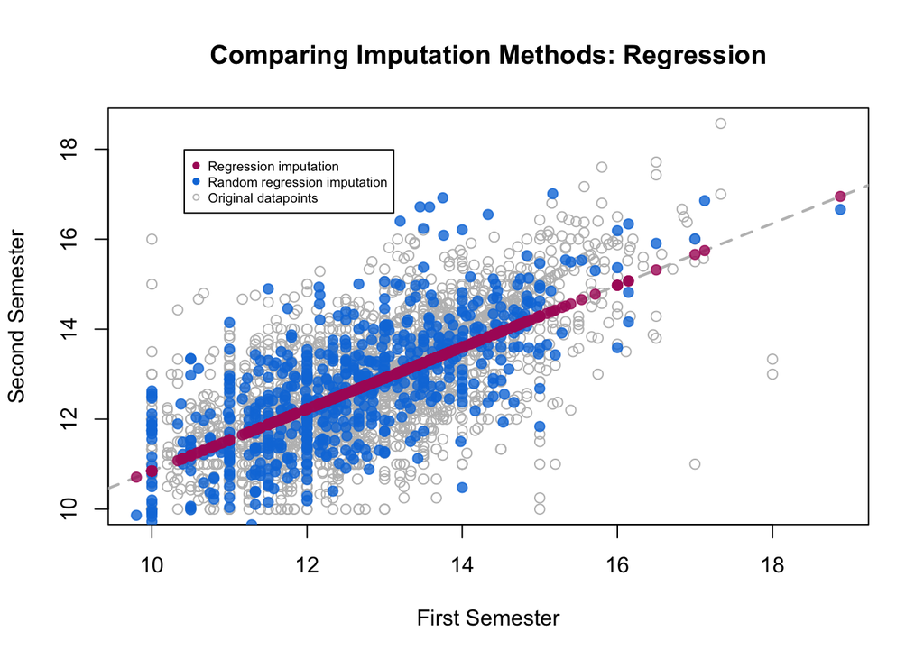

```r
pred.mdl = lm(Grade2~Grade1, data = data)
newdata = data[is.na(data$Grade2),]
pred.y = predict(pred.mdl, newdata = newdata)
m0 = sum(is.na(data$Grade2))      # total number of missing values
pred.resid = resid(pred.mdl)    # residual
pred.yrand = pred.y + sample(pred.resid, m0, replace = TRUE)

# Create a plot
plot(data$Grade1, data$Grade2, main = "Comparing Imputation Methods: Regression", xlab = "First Semester", ylab = "Second Semester", col = "gray")

# plot a regression line
abline(pred.mdl, col = "gray", lty = 2, lwd = 2)

# Plot points
points(newdata$Grade1, pred.yrand, pch = 19, col = rgb(12/255, 123/255, 220/255, alpha = .8))
points(newdata$Grade1, pred.y, pch = 19, col = rgb(172/255, 31/255, 103/255, alpha = .8))

# Add the legend
legend("topleft",
       legend = c("Regression imputation", "Random regression imputation", "Original datapoints"),
       col = c(rgb(172/255, 31/255, 103/255, alpha = 1), rgb(12/255, 123/255, 220/255, alpha = 1), rgb(128/255, 128/255, 128/255, alpha = .5)),
       pch = c(19, 19, 1),
       xpd = TRUE,
       inset = c(.1, .1),   # Adjust inset
       cex = 0.6)             # Smaller font size (default is 1)
```

### 3.1.3 Multiple Imputation

I perform multiple imputation for grades by chained equations through the MICE package using predictive mean matching for the grade features, which produces a close fit with the data while still maintaining randomness and variability.

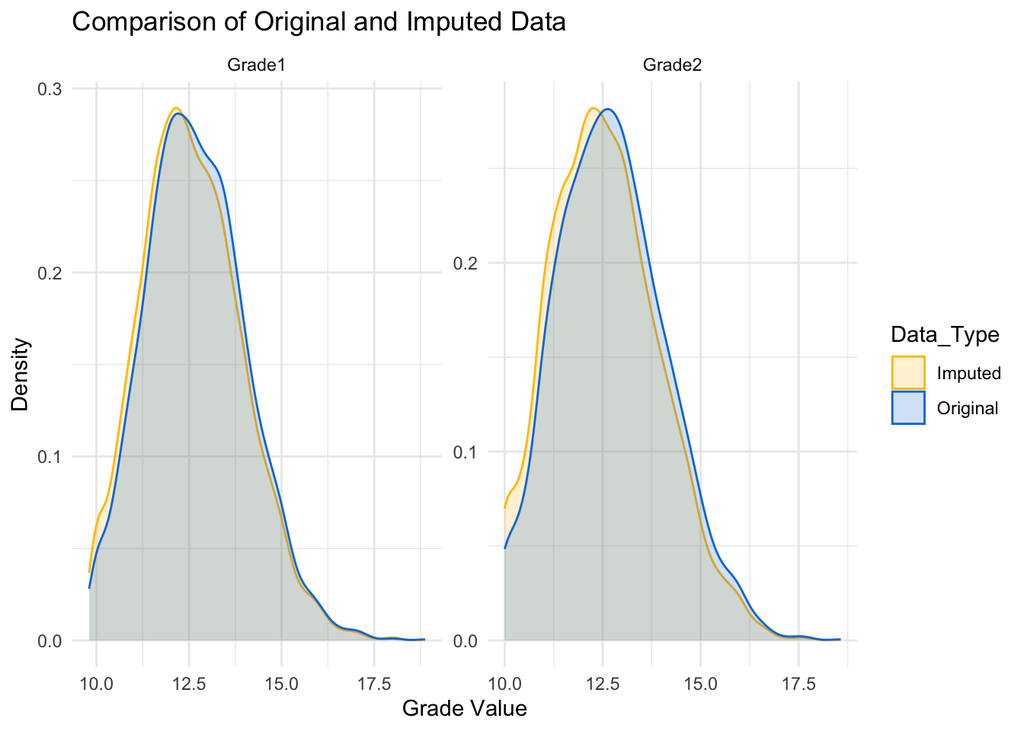

```r
#create a new dataframe to test MICE algorithm
grades <- data

# Use Predictive Mean Matching (PMM) for the continuous features to perform MICE imputation
imputed_data1 <- mice(grades, method = "pmm", m = 4, maxit = 5, seed = 14)

#Fit model to imputed dataset
model_imp_2 <- with(imputed_data1, lm(grades$Grade2 ~ grades$Grade1))

#Combine parameter estimates
pooled_results2 <- pool(model_imp_2)

# Summarize results
invisible(summary(pooled_results2))

# View the imputed data (completed dataset)
completed_data <- complete(imputed_data1)

# Add a new column to differentiate original vs imputed data
grades$Data_Type <- "Original"
completed_data$Data_Type <- "Imputed"

# Combine original and imputed data into one data frame
combined_data <- rbind(
  data.frame(Grade1 = grades$Grade1, Grade2 = grades$Grade2, Data_Type = grades$Data_Type),
  data.frame(Grade1 = completed_data$Grade1, Grade2 = completed_data$Grade2, Data_Type = completed_data$Data_Type)
)

# Reshape the data from wide to long format for ggplot
long_data <- gather(combined_data, key = "Grade_Type", value = "Grade_Value", Grade1, Grade2)

# Plot a layered density plot for Grade1 and Grade2
ggplot(long_data, aes(x = Grade_Value, fill = Data_Type, color = Data_Type)) +
  geom_density(alpha = 0.2) +  # Add density curves with transparency
  facet_wrap(~Grade_Type, scales = "free", ncol = 2) +  # Facet for Grade1 and Grade2
  labs(title = "Comparison of Original and Imputed Data",
       x = "Grade Value", y = "Density") +
  scale_fill_manual(values = c("Original" = "#0C7BDC", "Imputed" = "#FFC20A")) +
  scale_color_manual(values = c("Original" = "#0C7BDC", "Imputed" = "#FFC20A")) +
  theme_minimal()  # Apply minimal theme
```

## 3.2 Feature Engineering

In this section, I will address skewness and other potential issues in key features and apply transformation methods to improve feature distribution and prepare the data for regression modeling.

### 3.2.1 Feature Transformation

I create a new feature that averages first and second semester grades to combine information from both features.

```r
data2 <- completed_data

data2$avg_grade <- (data2$Grade1 + data2$Grade2)/2 # create grade average feature
```

Next, to transform the grade features into more normalized distributions, I perform Box-Cox transformations. Following imputation, all values are positive and there are no missing or zero values.

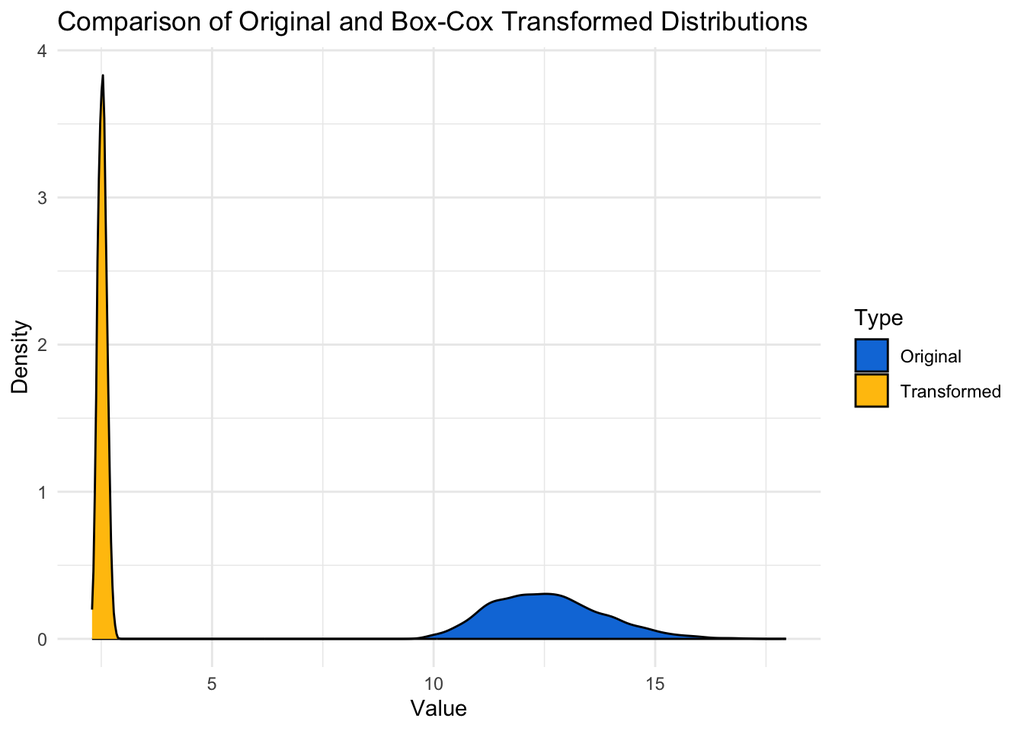

I also combine information about student grade averages originally recorded as zero in a new feature called Zero. This feature categorizes students into three categories: 0 for no recorded grade average of zero, 1 for 1 semester with a recorded grade average of zero, and 2 for both semesters with a recorded grade average of zero.

```r
data2$Zero <- data2$Zero1 + data2$Zero2
```

Lastly, I recode the Target feature so that its values are numeric and create a binary, numerically encoded Dropout feature based on the Target that indicates whether a student is recorded to have dropped out of their course of study.

### 3.2.2 Feature Grouping

In this section, I will use strategies to combine and group information across key features to prepare the data for modeling and ensure interpretability.

This dataset includes multiple features measuring curricular units for each semester, including the number of curricular units credited, enrolled, approved, and evaluated. A significant number of the credited features for each semester have a value of zero, more so in the second semester; this may indicate that the information was recorded before the end of the second semester and may be incomplete. The distribution of approved curricular units is the closest to normal among all curricular unit features, so I proceed with this feature based on the assumption that these features capture overlapping information. I then combine the first and second semester approved curricular units in a new called AppUnit, which measures the total approved curricular units for a student’s first year. To improve interpretability, I bin the new feature into category ranges (note that these ranges were established based on research into average curricular units in Portugal as well as an evaluation of the feature distribution):

- 0, which would be considered no curricular units approved for either semester
- 1-5, which could be considered few curricular units approved
- 6-9, which could be considered a low but typical range of curricular units approved
- 10-12, which could be considered a typical range of curricular units approved
- 13-16, which could be considered a high but typical range of curricular units
- 17+, which could be considered the highest range of curricular units

Finally, I encode the new categorical feature to prepare it for modeling.

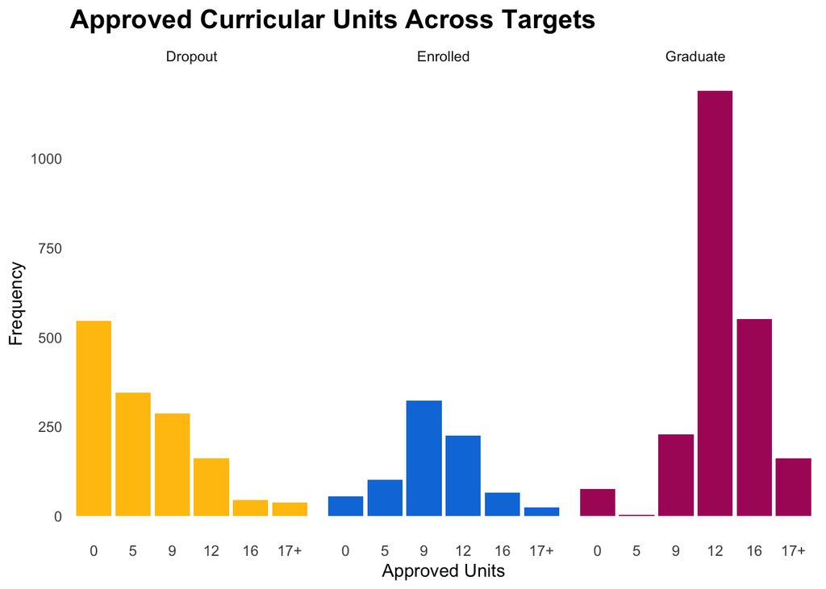

```r
data2$AppUnit <- (data2$U_Approved2 + data2$U_Approved1) #create a new combined approved credits

# Bin average approved units
data2$AppUnit <- cut(data2$AppUnit,
                        breaks = c(-Inf, 0, 5, 9, 12, 16, Inf),
                        labels = c("0", "5", "9", "12", "16", "17+"),
                        right = TRUE)

# side by side grouped bar charts
ggplot(data2, aes(x = AppUnit, fill = Target)) +
  geom_bar(position = "dodge") +  # Use dodge to create side-by-side bars
  scale_fill_manual(values = c("#FFC20A", "#0C7BDC", "#ac1f67")) +  # Custom colors
  labs(title = "Approved Curricular Units Across Targets",
       x = "Approved Units",
       y = "Frequency",
       fill = "Target Categories") +  # Label the fill (legend)
  theme_minimal() +
  theme(
    legend.position = "none",
    axis.text.x = element_text(size = 9),  # Adjust size of x-axis labels
    plot.title = element_text(size = 16, face = "bold"),  # Increase title size and make it bold
    panel.grid = element_blank()  # Remove gridlines
  ) +
  facet_wrap(~ Target)  # Create separate bar charts for each Target category
```

```r
data2 <- data2 %>%
  mutate(Target = recode(Target,
                         "Dropout" = 0,
                         "Enrolled" = 1,
                         "Graduate" = 2))

data2$Dropout <- ifelse(data2$Target == 0, 1, 0)
```

```r
data2$AppUnit <- recode(data2$AppUnit, "0" = 0, "5" = 1, "9" = 2, "12" = 3, "16" = 4, "17+" = 5)
```

## 3.3 Feature Selection

To proceed with model building, I remove irrelevant or redundant features. Section 3.2 outlined the steps taken to combine information for key features, including grades and curricular units. I remove the original features whose information the newly created or transformed features captured.

What follows is a summary of the features that will be considered in developing machine learning models. For ease of reference, these have been grouped by type into student background and demographic, student financial, macroeconomic, and academic features.

**Student Background and Demographic Features**

- **Marital Status** (categorical): 6 numerically encoded categories include single, married, widower, divorced, de facto union, or legally separated.
- **Application mode** (categorical): 18 numerically encoded categories include information related to the student’s application classifiers, such as international student, special contingent, special age category, and transfer student.
- **Application order** (categorical): 8 numerically encoded categories of preferred application order between first choice and last choice.
- **Nationality** (categorical): 21 numerically encoded nationalities represented.
- **Mother’s Qualification** and **Father’s Qualification** (categorical): 29 and 34 numerically encoded categories of highest education level, respectively.
- **Mother’s Occupation** and **Father’s Occupation** (categorical): 32 and 46 numerically encoded categories of occupation, respectively.
- **Educational special needs** (binary): Whether or not a student has educational special needs; numerically encoded.
- **Gender** (binary): This feature has just two categories and is numerically encoded.
- **Scholarship holder** (binary): Whether or not a student holds a scholarship; numerically encoded.
- **Age at enrollment** (integer): Age of the student when they are enrolled.
- **International student** (binary): Whether or not a student is international (in this case, not from Portugal); numerically encoded.
- **Displaced** (binary): Whether or not a student is displaced; numerically encoded.

**Student Financial Features**

- **Debtor** (binary): Whether or not a student has debt; numerically encoded.
- **Tuition fees up to date** (binary): Whether or not a student’s tuition fees are up to date; numerically encoded.

**Student Academic Features**

- **Course** (categorical): 17 numerically encoded categories for chosen course of study.
- **Daytime/evening attendance** (binary): Whether a student attends during the day or in the evening; numerically encoded.
- **Previous Qualification** (categorical): 17 numerically encoded categories of highest education level, from secondary education to master’s degree.
- **Approved Curricular Units** (categorical): The number of approved curricular units for the first and second semester.
- **Target** (categorical): A student’s academic outcome, numerically encoded and classified as dropout, graduate, enrolled.
- **Dropout** (binary): Whether or not a student dropped out of university; numerically encoded.

**Macroeconomic Features**

- **Unemployment Rate** (continuous): Unemployment rate at the time of student enrollment.
- **Inflation Rate** (continuous): Inflation rate at the time of student enrollment.
- **GDP** (continuous): GDP at the time of student enrollment.

```r
# create a new dataset that removes redundant features
data3 <- subset(data2, select = -c(U_Credited1, U_Enrolled1, U_Evaluated1, U_Approved1, Grade1, U_WO_Eval1, U_Credited2, U_Enrolled2, U_Evaluated2, U_Approved2, Grade2, U_WO_Eval2, Data_Type, Target, Zero1, Zero2, avg_grade))
```

# 4 Model Development

The purpose of this portion of the report is to use machine learning methods to build, select, and cross-validate regression models that accurately predict university students’ academic outcomes. First, I will explore whether macroeconomic factors contribute to predicting student grades through linear regression modeling. Then, I will consider models to predict whether or not a student will drop out of their university education.

## 4.1 Linear Regression Model to Predict Second-Semester Grades

In the training phase, I eliminate features from the model and compare the performance in a step-wise selection. I then compare the final model with a model fitted via robust linear regression. To evaluate the models, I will run them in my validation dataset and compare their respective mean squared errors.

The candidate models are:

- **Model 1**: Second-semester average grade = 0.80203664 + 0.6675831(First-semester average grade) + 0.0030190(Unemployment) + 0.0023759(Inflation)
- **Model 2**: Second-semester average grade = 0.6965 + 0.7091(First-semester average grade) + 0.0030(Unemployment) + 0.0022(Inflation)

```r
# create a dataset with only the relevant continuous features
data4 <- data2[, c("Unemployment", "GDP", "Inflation", "g1_transformed", "g2_transformed")]

colnames(data4) <- c("Unemployment", "Inflation", "GDP", "Grade1", "Grade2")

# Set a seed for reproducibility
set.seed(104)

# Define sample sizes
n <- nrow(data4)  # Total number of observations
size_80 <- round(0.80 * n)  # 80% subset
size_15 <- round(0.15 * n)  # 15% subset
size_5  <- n - size_80 - size_15  # Remaining 5%

# Randomly shuffle row indices
indices <- sample(n)

# Assign subsets
Subset2_80 <- data4[indices[1:size_80], ]
Subset2_15 <- data4[indices[(size_80 + 1):(size_80 + size_15)], ]
Subset2_5  <- data4[indices[(size_80 + size_15 + 1):n], ]
```

```r
# Fit a full linear regression model with all predictors
g2m1 <- lm(Grade2 ~ Grade1 + GDP + Unemployment + Inflation, data = Subset2_80)

# Perform stepwise selection (default is backward elimination)
step_model1 <- step(g2m1, direction = "both")

summary(step_model1)
```

```r
# Robust linear regression
g2m3 <- rlm(Grade2 ~ Grade1 + Unemployment + Inflation, data = Subset2_80)

# Summary
summary(g2m3)
```

### 4.1.1 Validation

Next, I use a 15% subset of the dataset to validate the two models and compare their mean squared errors. I find that Model 1 has the lowest mean squared error (0.006239).

```r
Subset2_15$linear_model1 = 0.80203664 + 0.6675831*Subset2_15$Grade1 + 0.0030190*Subset2_15$Unemployment + 0.0023759*Subset2_15$Inflation

Subset2_15$linear_model2 = 0.6965 + 0.7091*Subset2_15$Grade1 + 0.0030*Subset2_15$Unemployment + 0.0022*Subset2_15$Inflation

# Get actual values
Subset2_15$Grade2

# Compute Mean Squared Error (MSE)
MSE_m1 <- mean((Subset2_15$Grade2 - Subset2_15$linear_model1)^2)
MSE_m2 <- mean((Subset2_15$Grade2 - Subset2_15$linear_model2)^2)
```

Next, I refit the model using my combined 80% and 15% data subsets, and find a mean squared error of 0.006683.

```r
Subset2_15_edited <- Subset2_15[, c("Grade1", "Grade2", "Inflation", "GDP", "Unemployment")]
Subset2_80_edited <- Subset2_80[, c("Grade1", "Grade2", "Inflation", "GDP", "Unemployment")]

Subset2_15and80 <- rbind(Subset2_15_edited, Subset2_80_edited)

g2m2_refit <- lm(Grade2 ~ Grade1 + Inflation + Unemployment, data = Subset2_15and80)

summary(g2m2_refit)

# Get predicted values
predicted_g2m2_values_test2 <- fitted(g2m2_refit)

actual_g2_values_test2 <- Subset2_15and80$Grade2

# Compute Mean Squared Error (MSE)
MSE_g2m2_test2 <- mean((actual_g2_values_test2 - predicted_g2m2_values_test2)^2)
```

### 4.1.2 Linear Regression Equation and Performance

I test Model 1 using the reserved 5% subsetted data, which yields a mean squared error of 0.006733 and an $R^2$ value of 0.5097.

What follows is the final linear regression equation for Model 1 and a plot visualizing its performance. The scatter plot compares actual second-semester grades with grades predicted by Model 1.

Let $Y$ = Second-semester average grade, and let:

- $X_1$ = First-semester average grade
- $X_2$ = Unemployment Rate
- $X_3$ = Inflation Rate

$$Y = 0.7991693 + 0.6692239X_1 + 0.0028986X_2 + 0.0023252X_3$$

### 4.1.3 Discussion

This model includes both unemployment rate and inflation rate, so macroeconomic factors appear to have some predictive influence on a students’ grades and thus may be considered in machine learning models to predict academic performance.

However, this model is limited due to the dataset; the majority of features in this dataset are categorical or otherwise not conducive to linear regression modeling. The few continuous features included may not be optimal for predicting students’ average grades.

```r
Subset2_5$Predicted <- 0.7991693 + 0.6692239*Subset2_5$Grade1 + 0.0023252*Subset2_5$Inflation + 0.0028986*Subset2_5$Unemployment

predicted_g2m2_values_final <- Subset2_5$Predicted
actual_g2_values_final <- Subset2_5$Grade2

# Compute Mean Squared Error (MSE)
MSE_g2m2_final <- mean((actual_g2_values_final - predicted_g2m2_values_final)^2)

# Compute the mean of actual values
mean_actual <- mean(actual_g2_values_final)

# Compute Total Sum of Squares (SST)
SST <- sum((actual_g2_values_final - mean_actual)^2)

# Compute Residual Sum of Squares (SSE)
SSE <- sum((actual_g2_values_final - predicted_g2m2_values_final)^2)

# Calculate R-squared (R²)
R_squared <- 1 - (SSE / SST)
```

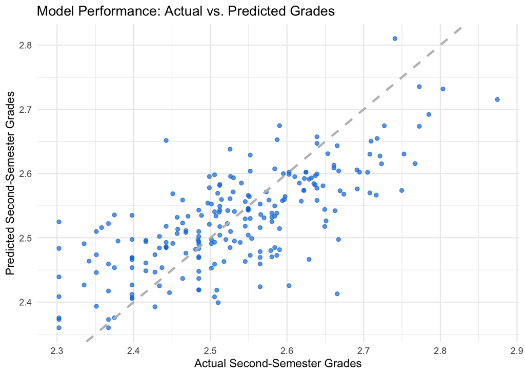

```r
# Create a dataframe for plotting
plot_data <- data.frame(
  Actual = Subset2_5$Grade2,       # Actual values
  Predicted = Subset2_5$Predicted  # Predicted values
)

# Create the scatter plot
ggplot(plot_data, aes(x = Actual, y = Predicted)) +
  geom_point(color = "#0C7BDC", alpha = 0.7) +  # Scatter points (blue)
  geom_abline(slope = 1, intercept = 0, linetype = "dashed", color = "gray", size = 1) +  # 45-degree line
  labs(title = "Model Performance: Actual vs. Predicted Grades",
       x = "Actual Second-Semester Grades",
       y = "Predicted Second-Semester Grades") +
  theme_minimal()
```

## 4.2 Logistic Regression Model to Predict Student Dropout

In this section, I develop a logistic regression model to predict the binary outcome of whether a student will drop out of their course of study based on relevant features in the dataset.

I begin by splitting the data into three portions for training (80%), validation (15%), and testing (5%).

```r
# Set a seed for reproducibility
set.seed(104)

# Define sample sizes
n <- nrow(data3)  # Total number of observations
size_80 <- round(0.80 * n)  # 80% subset
size_15 <- round(0.15 * n)  # 15% subset
size_5  <- n - size_80 - size_15  # Remaining 5%

# Randomly shuffle row indices
indices <- sample(n)

# Assign subsets
Subset3_80 <- data3[indices[1:size_80], ]
Subset3_15 <- data3[indices[(size_80 + 1):(size_80 + size_15)], ]
Subset3_5  <- data3[indices[(size_80 + size_15 + 1):n], ]
```

### 4.2.1 Model Selection

To begin reducing dimensionality in the model, I consider all features using step-wise selection, which returns 16 features that may be relevant in predicting student dropout status: Marital Status, Application Mode, Application Order, Course of Study, Day or Evening Attendance, Mother’s Qualification, Mother’s Occupation, Tuition Status, Gender, Scholarship, Age, International Student, Unemployment Rate, Average Grade, and Approved Curricular Units.

I proceed by eliminating features one at a time and comparing the resulting and original models’ ROC curves to determine which features add to the model’s predictive accuracy. Below is a brief summary of three of these candidate models and a comparison of their ROC curves.

```r
m1 <- glm(Dropout ~ Marital + Application_M + Application_O +
    Course + Attendance + M_Qual + M_Occ + Tuition +
    Gender + Scholarship + Age + International + Unemployment +
    avg_grade_transformed + Zero + AppUnit, data = Subset3_80, family = binomial)

summary(m1)

# Get predicted values
Subset3_80$Model1 <- fitted(m1)
```

```r
m2 <- glm(Dropout ~ Tuition + avg_grade_transformed + AppUnit + Course, data = Subset3_80, family = binomial)

summary(m2)

# Get predicted values
Subset3_80$Model2 <- fitted(m2)
```

```r
m3 <- glm(Dropout ~ avg_grade_transformed + AppUnit + Tuition, data = Subset3_80, family = binomial)

summary(m3)

# Get predicted values
Subset3_80$Model3 <- fitted(m3)
```

```r
# Select necessary columns
loop3_80 <- subset(Subset3_80, select = c(Dropout, Model1, Model2, Model3))

# Define cutoff thresholds
cutoffs <- seq(0, 1, by = 0.05)

# Initialize a list to store confusion matrices
conf_matrices <- list()

# Models to process
models <- c("Model1", "Model2", "Model3")

# Loop through models
for (model in models) {

  # Create cutoff features dynamically
  for (c in cutoffs) {
    col_name <- paste0("cutoff_", model, "_", c)  # Generate column name
    loop3_80[[col_name]] <- ifelse(loop3_80[[model]] > c, 1, 0)  # Apply cutoff
  }

  # Loop through each cutoff threshold to compute confusion matrix
  for (c in cutoffs) {
    col_name <- paste0("cutoff_", model, "_", c)  # Dynamic column name

    # Initialize confusion matrix counters
    TP <- sum(loop3_80$Dropout == 1 & loop3_80[[col_name]] == 1)
    FP <- sum(loop3_80$Dropout == 0 & loop3_80[[col_name]] == 1)
    TN <- sum(loop3_80$Dropout == 0 & loop3_80[[col_name]] == 0)
    FN <- sum(loop3_80$Dropout == 1 & loop3_80[[col_name]] == 0)

    # Store confusion matrix for this cutoff and model
    conf_matrices[[col_name]] <- matrix(c(TP, FP, FN, TN), nrow = 2, byrow = TRUE,
                                        dimnames = list("Actual" = c("Positive", "Negative"),
                                                        "Predicted" = c("Positive", "Negative")))
  }
}
```

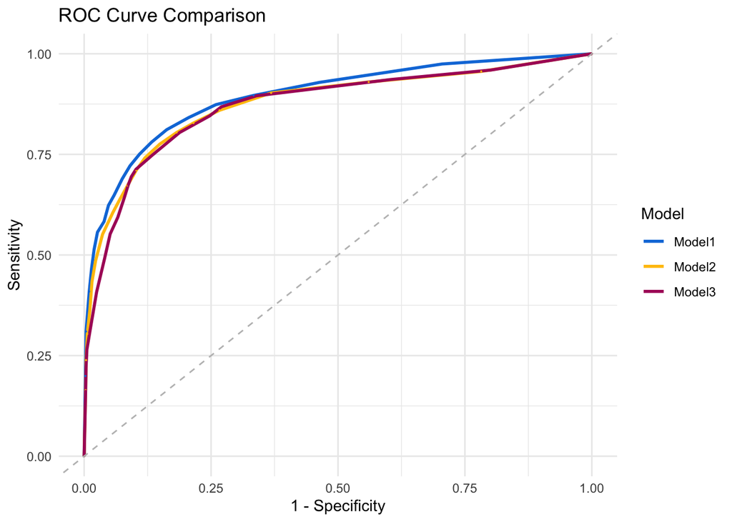

```r
# Create an empty data frame to store ROC values for each model
roc_data <- data.frame(
  Model = character(),
  Cutoff = numeric(),
  FPR = numeric(),
  TPR = numeric()
)

# Loop through models and calculate FPR & TPR
for (model in models) {
  for (i in seq_along(cutoffs)) {
    cutoff_name <- paste0("cutoff_", model, "_", cutoffs[i])
    conf_matrix <- conf_matrices[[cutoff_name]]

    # Extract TP, FP, TN, FN
    TP <- conf_matrix[1, 1]  # True Positives
    FP <- conf_matrix[1, 2]  # False Positives
    FN <- conf_matrix[2, 1]  # False Negatives
    TN <- conf_matrix[2, 2]  # True Negatives

    # Compute False Positive Rate (FPR) and True Positive Rate (TPR)
    FPR <- FP / (FP + TN)
    TPR <- TP / (TP + FN)

    # Append to roc_data
    roc_data <- rbind(roc_data, data.frame(Model = model, Cutoff = cutoffs[i], FPR = FPR, TPR = TPR))
  }
}

# Convert Model column to a factor for proper legend labeling
roc_data$Model <- factor(roc_data$Model, levels = models)

# Plot ROC Curves for all three models
ggplot(roc_data, aes(x = FPR, y = TPR, color = Model, group = Model)) +
  geom_line(size = 1) +  # Line plot for each model
  geom_point(size = 0) +  # Hide points for cutoffs
  geom_text(aes(label = sprintf("%.2f", Cutoff)), vjust = -0.8, hjust = 0.8, size = 0) +  # Hide labels
  scale_color_manual(values = c("Model1" = "#0C7BDC",
                                "Model2" = "#FFC20A",
                                "Model3" = "#ac1f67")) +
  labs(title = "ROC Curve Comparison",
       x = "1 - Specificity",
       y = "Sensitivity",
       color = "Model") +
  theme_minimal() +
  geom_abline(slope = 1, intercept = 0, linetype = "dashed", color = "gray")  # Add diagonal reference line
```

To evaluate the models, I look at the area under the ROC curve. Model 1 has the highest area under the curve (0.8962), followed by Model 2 (0.8762) and Model 3 (0.8708). For the sake of model simplicity and reduced dimensionality, I will proceed with Model 2.

```r
# Initialize a list to store AUC values
auc_values <- list()

# Loop through models to compute AUC
for (model in models) {
  roc_curve <- roc(loop3_80$Dropout, loop3_80[[model]])  # Compute ROC curve
  auc_values[[model]] <- auc(roc_curve)  # Store AUC value
}
```

### 4.2.2 Cross Validation

Next, I deploy cross-validation techniques to find the optimal cutoff for the model. I first combine my reserved 15% dataset with the 80% dataset before subsetting them into six datasets. I use these six datasets to cross-validate and test my logistic regression model in six phases.

```r
Subset3_80_edited <- subset(Subset3_80, select = c(Tuition, avg_grade_transformed, AppUnit, Course, Dropout))

Subset3_15_edited <- subset(Subset3_15, select = c(Tuition, avg_grade_transformed, AppUnit, Course, Dropout))

Subset3_95 <- rbind(Subset3_80_edited, Subset3_15_edited)

colnames(Subset3_95) <- c("X1", "X2", "X3", "X4", "Dropout")

set.seed(105)

Subset3_95 <- Subset3_95 %>% mutate(group = sample(1:6, n(), replace = TRUE))  # Assign random groups

data_list <- Subset3_95 %>% group_split(group)  # Split into 6 datasets

# Extract individual datasets
S1 <- data_list[[1]]
S2 <- data_list[[2]]
S3 <- data_list[[3]]
S4 <- data_list[[4]]
S5 <- data_list[[5]]
S6 <- data_list[[6]]

# List of datasets
datasets <- list(S1, S2, S3, S4, S5, S6)

# Generate six unique combinations, each excluding one dataset
dataset_combinations <- list(
  list(S1, S2, S3, S4, S5),  # Excluding S6
  list(S2, S3, S4, S5, S6),  # Excluding S1
  list(S1, S3, S4, S5, S6),  # Excluding S2
  list(S1, S2, S4, S5, S6),  # Excluding S3
  list(S1, S2, S3, S5, S6),  # Excluding S4
  list(S1, S2, S3, S4, S6)   # Excluding S5
)

# Bind the selected datasets row-wise to create the Phase datasets
Phase1 <- do.call(rbind, dataset_combinations[[1]]) # Excluding S6
Phase2 <- do.call(rbind, dataset_combinations[[2]]) # Excluding S1
Phase3 <- do.call(rbind, dataset_combinations[[3]]) # Excluding S2
Phase4 <- do.call(rbind, dataset_combinations[[4]]) # Excluding S3
Phase5 <- do.call(rbind, dataset_combinations[[5]]) # Excluding S4
Phase6 <- do.call(rbind, dataset_combinations[[6]]) # Excluding S5
```

```r
# Define logistic equation function
compute_prob <- function(df) {
  df$prob <- exp(9.49795 - 2.70573 * df$X1 - 2.56287 * df$X2 - 1.06728 * df$X3 + 0.08628 * df$X4) /
             (1 + exp(9.49795 - 2.70573 * df$X1 - 2.56287 * df$X2 - 1.06728 * df$X3 + 0.08628 * df$X4))
  return(df)
}

# Define function to find optimal cutoff
find_optimal_cutoff <- function(df) {
  cutoffs <- seq(0, 1, by = 0.01)  # Cutoff range from 0 to 1 in steps of 0.01
  results <- data.frame(Cutoff = cutoffs, Sensitivity = NA, Specificity = NA, YoudenIndex = NA)

  # Loop through cutoff values
  for (i in seq_along(cutoffs)) {
    c <- cutoffs[i]

    # Create prediction feature based on cutoff
    df$pred <- ifelse(df$prob > c, 1, 0)

    # Compute confusion matrix
    cm <- table(Predicted = df$pred, Actual = df$Dropout)

    # Extract True Positives (TP), False Positives (FP), True Negatives (TN), and False Negatives (FN)
    TP <- ifelse("1" %in% rownames(cm) & "1" %in% colnames(cm), cm["1", "1"], 0)
    FP <- ifelse("1" %in% rownames(cm) & "0" %in% colnames(cm), cm["1", "0"], 0)
    TN <- ifelse("0" %in% rownames(cm) & "0" %in% colnames(cm), cm["0", "0"], 0)
    FN <- ifelse("0" %in% rownames(cm) & "1" %in% colnames(cm), cm["0", "1"], 0)

    # Calculate Sensitivity (Recall) and Specificity
    Sensitivity <- ifelse((TP + FN) > 0, TP / (TP + FN), 0)
    Specificity <- ifelse((TN + FP) > 0, TN / (TN + FP), 0)

    # Compute Youden's Index (Sensitivity + Specificity - 1)
    YoudenIndex <- Sensitivity + Specificity - 1

    # Store results
    results[i, ] <- c(c, Sensitivity, Specificity, YoudenIndex)
  }

  # Find the cutoff with the highest Youden’s Index
  best_cutoff <- results$Cutoff[which.max(results$YoudenIndex)]

  return(best_cutoff)
}

# Store Phases in a list
Phase_List <- list(Phase1, Phase2, Phase3, Phase4, Phase5, Phase6)

# Loop through each Phase, apply logistic equation, and find optimal cutoff
optimal_cutoffs <- c()

for (i in seq_along(Phase_List)) {
  Phase_List[[i]] <- compute_prob(Phase_List[[i]])  # Apply logistic equation
  best_cutoff <- find_optimal_cutoff(Phase_List[[i]])  # Find optimal cutoff
  optimal_cutoffs <- c(optimal_cutoffs, best_cutoff)  # Store optimal cutoff
}
```

```r
# Define function to compute accuracy
compute_accuracy <- function(df, cutoff) {
  # Apply the cutoff to generate predictions
  df$pred <- ifelse(df$prob > cutoff, 1, 0)

  # Compute confusion matrix
  cm <- table(Predicted = df$pred, Actual = df$Dropout)

  # Extract True Positives (TP), False Positives (FP), True Negatives (TN), and False Negatives (FN)
  TP <- ifelse("1" %in% rownames(cm) & "1" %in% colnames(cm), cm["1", "1"], 0)
  FP <- ifelse("1" %in% rownames(cm) & "0" %in% colnames(cm), cm["1", "0"], 0)
  TN <- ifelse("0" %in% rownames(cm) & "0" %in% colnames(cm), cm["0", "0"], 0)
  FN <- ifelse("0" %in% rownames(cm) & "1" %in% colnames(cm), cm["0", "1"], 0)

  # Compute accuracy: (TP + TN) / Total observations
  total <- TP + FP + TN + FN
  accuracy <- ifelse(total > 0, (TP + TN) / total, 0)

  return(accuracy)
}

# Define the list of testing datasets (excluded datasets from each phase)
testing_datasets <- list(S6, S1, S2, S3, S4, S5)

# Optimal cutoffs from previous results
optimal_cutoffs <- c(0.34, 0.34, 0.39, 0.34, 0.41, 0.39)

# Loop through each testing dataset, apply cutoff, and compute accuracy
accuracy_results <- c()

for (i in seq_along(testing_datasets)) {
  testing_datasets[[i]] <- compute_prob(testing_datasets[[i]])  # Compute probability
  accuracy <- compute_accuracy(testing_datasets[[i]], optimal_cutoffs[i])  # Compute accuracy
  accuracy_results <- c(accuracy_results, accuracy)  # Store accuracy result
}
```

```r
# Define the values
CT <- c(0.34, 0.34, 0.39, 0.34, 0.41, 0.39)
AT <- c(80.66, 80.61, 85.42, 82.81, 83.68, 83.22)  # As percentages
AUCT <- c(0.8543, 0.8592, 0.8988, 0.8891, 0.8847, 0.8885)

# Create a data frame
results_table <- data.frame(
  Phase = paste0("Phase ", 1:6),
  Cutoff = CT,
  Accuracy = paste0(AT, "%"),  # Format accuracy with percentage symbol
  AUC = AUCT
)

# Print the table using kable()
kable(results_table, title = "Model Performance Metrics for Each Phase")
```

| Phase | Cutoff | Accuracy | AUC |
| --- | --- | --- | --- |
| Phase 1 | 0.34 | 80.66% | 0.8543 |
| Phase 2 | 0.34 | 80.61% | 0.8592 |
| Phase 3 | 0.39 | 85.42% | 0.8988 |
| Phase 4 | 0.34 | 82.81% | 0.8891 |
| Phase 5 | 0.41 | 83.68% | 0.8847 |
| Phase 6 | 0.39 | 83.22% | 0.8885 |

```r
# Define function to compute AUC
compute_auc <- function(df) {
  roc_curve <- roc(df$Dropout, df$prob)  # Compute ROC curve
  auc_value <- auc(roc_curve)  # Extract AUC
  return(auc_value)
}

# Define the list of testing datasets (excluded datasets from each phase)
testing_datasets <- list(S6, S1, S2, S3, S4, S5)

# Loop through each testing dataset, compute AUC
auc_results <- c()

for (i in seq_along(testing_datasets)) {
  testing_datasets[[i]] <- compute_prob(testing_datasets[[i]])  # Compute probability
  auc_value <- compute_auc(testing_datasets[[i]])  # Compute AUC
  auc_results <- c(auc_results, auc_value)  # Store AUC result
}
```

The cross-validation method yields an average optimal cutoff of 0.3683. With the remaining 5% of the data, I test the accuracy of Model 2 and find that the model is 80.54% accurate with an AUC of 0.8208.

```r
Subset3_5 <- subset(Subset3_5, select = c(Tuition, avg_grade_transformed, AppUnit, Course, Dropout))

colnames(Subset3_5) <- c("X1", "X2", "X3", "X4", "Dropout")

# Set the average optimal cutoff
average_cutoff <- 0.3683

# Compute probability for Subset3_5
Subset3_5 <- compute_prob(Subset3_5)

# Compute accuracy and AUC for Subset3_5
accuracy_Subset3_5 <- compute_accuracy(Subset3_5, average_cutoff)
auc_Subset3_5 <- compute_auc(Subset3_5)
```

The final model tested on the full dataset has 83.23% accuracy for predicting whether a student will drop out of their course of study based on early indicators.

```r
# Run the equation for the full dataset
data3$prob <- exp(9.49795 - 2.70573*data3$Tuition - 2.56287 *data3$avg_grade_transformed - 1.06728*data3$AppUnit + 0.08628 * data3$Course) /
             (1 + exp(9.49795 - 2.70573*data3$Tuition - 2.56287 *data3$avg_grade_transformed - 1.06728*data3$AppUnit + 0.08628 * data3$Course))

# Compute accuracy and AUC for full dataset
accuracy_data3 <- compute_accuracy(data3, average_cutoff)
auc_data3 <- compute_auc(data3)
```

### 4.2.3 Logistic Regression Equation and Performance

What follows is the Model 2 logistic regression equation, where the probability that Y=1 is the probability of student dropout. The features are defined as follows:

- $X_1$ = Tuition Fees Up to Date (Binary)
- $X_2$ = Average Grade (First and Second Semester)
- $X_3$ = Approved Curricular Units (First and Second Semester)
- $X_4$ = Course of Study

$$P(Y=1)=\frac{e^{9.49795-2.70573X_1-2.56287X_2-1.06728X_3+0.08628X_4}}{1+e^{9.49795-2.70573X_1-2.56287X_2-1.06728X_3+0.08628X_4}}$$

### 4.2.4 Discussion

This model’s proven predictive accuracy may underperform that of a higher-dimensional model, but the model’s simplicity positions it for practicality in real-world applications. The model benefits from capturing diverse features that measure different factors contributing to student success, including those related to the student’s financial status as well as their academic pursuits and performance. This model can help flag students at risk of dropout by considering factors such as whether they are struggling academically or financially, or even whether they may benefit from a different course of study. Universities could potentially use this information to better understand and support their students’ needs.

# 5 Conclusion

Many factors influence students’ academic outcomes and thus models to predict those outcomes. This report considered the prediction problem from a machine learning perspective using regression modeling. Limitations include the dataset’s class bias, as discussed by the authors of *Early Prediction of Student’s Performance in Higher Education: A Case Study,*<sup>1</sup> and the need for reduced dimensionality in machine learning approaches.

The next recommended step would be to further evaluate the performance of the predictive models outlined in this report and address any bias perpetuated by the models.

Improving predictive models of students’ academic outcomes gives higher education institutions more information to make decisions about where to focus their resources and student support. Ultimately, an accurate and unbiased predictive model of student outcomes can help mitigate dropout rates and elevate higher education success.

# 6 References

1. Martins, M.V., Tolledo, D., Machado, J., Baptista, L.M.T., Realinho, V. (2021). Early Prediction of student’s Performance in Higher Education: A Case Study. In: Rocha, Á., Adeli, H., Dzemyda, G., Moreira, F., Ramalho Correia, A.M. (eds) Trends and Applications in Information Systems and Technologies. WorldCIST 2021. Advances in Intelligent Systems and Computing, vol 1365. Springer, Cham. https://doi.org/10.1007/978-3-030-72657-7_16
2. M.V.Martins, D. Tolledo, J. Machado, L. M.T. Baptista, V.Realinho. (2021). Predict Students’ Dropout and Academic Success. Kaggle. Attribution 4.0 International (CC BY 4.0). https://www.kaggle.com/datasets/harshitsrivastava25/predict-students-dropout-and-academic-success/data